# Test a Perceptual Phenomenon

### Analyzing the Stroop Effect

Perform the analysis in the space below. Remember to follow [the instructions](https://docs.google.com/document/d/1-OkpZLjG_kX9J6LIQ5IltsqMzVWjh36QpnP2RYpVdPU/pub?embedded=True) and review the [project rubric](https://review.udacity.com/#!/rubrics/71/view) before submitting. Once you've completed the analysis and write-up, download this file as a PDF or HTML file, upload that PDF/HTML into the workspace here (click on the orange Jupyter icon in the upper left then Upload), then use the Submit Project button at the bottom of this page. This will create a zip file containing both this .ipynb doc and the PDF/HTML doc that will be submitted for your project.

(1) What is the independent variable? What is the dependent variable?

dependent variable- time to perform a task i.e time to name ink colors. independent variable - is the condition (congruent,incongruent)

(2) What is an appropriate set of hypotheses for this task? Specify your null and alternative hypotheses, and clearly define any notation used. Justify your choices.

Null hypothesis - There is no diffrence in time taken for a population to state the colors of words in congruent or incongruent condition.

H0: μ(c)=μ(I) Alternative Hypothesis - The time taken for a population to state the colors of words in congruent condition are not equal to incongruent condition.

H(a): μ(c)!=μ(I)

where:

H(0)-> Null Hypothesis

H(a)-> Alternative Hypothesis

μ(c)-> Congruent population mean

μ(I)-> Incongruent population mean

Justification- we are doing two tailed hypothesis where null hypothesis is H0: μ(c)=μ(I) and alternate hypothesis is H(a): μ(c)!=μ(I) where μ(c) is mean time taken to name Congruent words and μ(I) is mean time taken to name Incongruent words. t-test is used as if the p-value is less than alpha(α) then we have to reject null hypothesis otherwise we fail to reject the null hypothesis.we are assuming error rate to be 5% that makes α=0.05.

(3) Report some descriptive statistics regarding this dataset. Include at least one measure of central tendency and at least one measure of variability. The name of the data file is 'stroopdata.csv'.

```python
# Perform the analysis here
import numpy as np;
import pandas as pd;
import matplotlib.pyplot as plt;
%matplotlib inline
df=pd.read_csv('stroopdata.csv');
df.head();

mean_congruent=df.Congruent.mean()
mean_incongruent=df.Incongruent.mean()

median_congruent=df.Congruent.median()
median_incongruent=df.Incongruent.median();

std_congruent=np.std(df['Congruent'])
std_incongruent=np.std(df['Incongruent'])

print('mean congruent is',mean_congruent)
print('mean incongruent is',mean_incongruent)
print('median congruent is',median_congruent)
print('median incongruent is',median_incongruent)
print('standard deviation congruent is',std_congruent)
print('standard deviation incongruent is',std_incongruent)
```

```
mean congruent is 14.051125
mean incongruent is 22.0159166667
median congruent is 14.3565
median incongruent is 21.0175
standard deviation congruent is 3.48441571277
standard deviation incongruent is 4.69605513451
```

we get

mean congruent is 14.051125

mean incongruent is 22.0159166667

median congruent is 14.3565

median incongruent is 21.0175

standard deviation congruent is 3.48441571277

standard deviation incongruent is 4.69605513451

These values give us the idea of dataset but we can't get much about these dataset by these values.

(4) Provide one or two visualizations that show the distribution of the sample data. Write one or two sentences noting what you observe about the plot or plots.

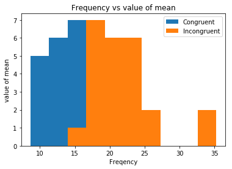

[figure not shown]

```python
# Build the visualizations here
df.plot.hist()#plot histogram with use of data frame df
plt.xlabel("Freqency"); # write the name for x-axis
plt.ylabel("value of mean");# write the name for y-axis
plt.title(" Frequency vs value of mean "); # write the title for graph
plt.show()# to show the graph

df.plot(kind='bar')#plot bar graph with use of data frame df
plt.xlabel('participants number')# write the name for x-axis
plt.ylabel('Time taken by participants')# write the name for y-axis
plt.title('Number of participants vs time taken by the participants')# write the title for graph
plt.show()# to show the graph
```

visualization 2:- shows participants number vs time taken by participants .The graphs shows that time taken to say incongruent words are more than congruent words.

(5) Now, perform the statistical test and report your results. What is your confidence level or Type I error associated with your test? What is your conclusion regarding the hypotheses you set up? Did the results match up with your expectations? **Hint:** Think about what is being measured on each individual, and what statistic best captures how an individual reacts in each environment.

```python
# Perform the statistical test here
from scipy import stats
stats.ttest_ind(df['Congruent'],df['Incongruent'])
```

```
Ttest_indResult(statistic=-6.5322505539032285, pvalue=4.5949489622951854e-08)
```

From the fact that that if pvalue is less than equla to alpha( pvalue <= α) then we reject null hypothesis.In this case we conclude that 4.5949489622951854e-08 <= 0.05 that is pvalue <= α therefore we reject null hypothesis Now we can say μ(c)!=μ(I) that he time taken for a population to state the colors of words in congruent condition are not equal to incongruent condition Therefore we reject null hypothesis.